# Data Visualisation with R - An introduction to ggplot

# Introduction to ggplot

Load relevant packages:

```r
pacman::p_load(tidyverse,lubridate,ggthemes,tidyquant,readr,readxl)

# load data:
Time_series <- read_csv("Time_series.csv")
Segment_Redemptions <- read_csv("CUSTOMER_ANALYTICS_SANDBOX_OUTPUT_REW_SEG.csv")
Redemptions_and_Total_Points <- read_csv("Redemptions_and_Total_Points.csv")
Sample_data <- read_excel("Sample_Data.xlsx",
      col_types = c(
      "numeric",
      "numeric",
      "numeric",
      "text",
      "numeric",
      "date",
      "numeric",
      "numeric",
      "numeric",
      "numeric",
      "numeric",
      "numeric",
      "numeric"))

theme_set(theme_bw())
```

## Anatomy of a ggplot object

GGplot is a grammar of graphics designed for composing graphics by combining independent components.

### Step 1: Format Data

Let’s do some quick formatting before plotting our data.

```r
# Some data wrangling, for plot prep:

# Filter the Time_series data frame to only include 2022, and reassign
# it to the same data frame:

Time_series %>%
  filter(year(DATE) == 2022) -> Time_series
```

### Step 2: Plot

## Line Plot

Another type of plot is the line plot, it is great for time series data, or data that has a temporal element:

```r
Time_series %>%
  filter(year(DATE) == 2022) %>%
# Canvas
  ggplot(aes(x = DATE, y = TOTAL_POINTS)) +
  # Geometries
  geom_line(size = 1, color="midnightblue") + # Adds a line
  geom_smooth(method = "lm", se = FALSE) + # Adds a smoothed line
  # Formatting
  expand_limits(y = 0) + # Adds 0 to the
  scale_y_continuous(labels = scales::number_format(scale = 1 / 1e6, suffix = "M")) +
  labs(
    title = "Point Redemptions 2022",
    subtitle = "Trend line indicates downward trend heading into peak season",
    x = "",
    y = "Points",
    caption = "Source: NDWHS_PROD.NDWHS_PL.BURN_FACT"
  ) -> g # Assign to an object
```

Inspect the ggplot element:

```r
# View(g)
```

# Types of Plots

## The Scatter Plot

The scatter plot is good for exploring the relationship between continuous variables. More advanced versions of this plot include the lollipop chart. Let’s look at the relation between Nectar points and value:

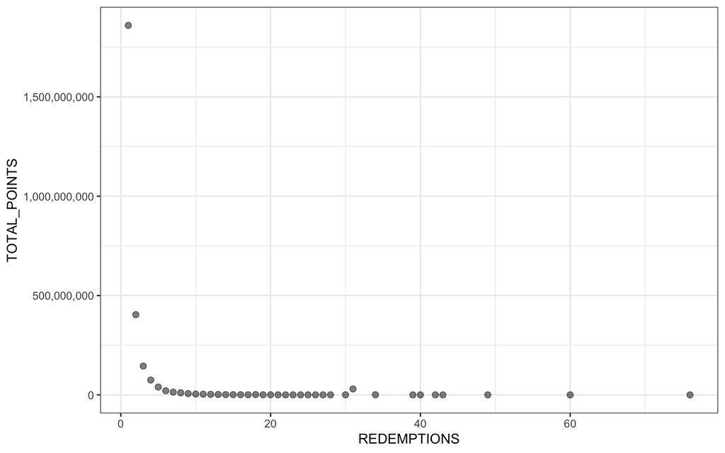

```r
# Data Manipulation:
points_dist <- Redemptions_and_Total_Points %>%

    select(REDEMPTIONS, TOTAL_POINTS) %>%

    group_by(REDEMPTIONS) %>%
    summarize(TOTAL_POINTS= sum(TOTAL_POINTS)) %>%
    ungroup()

# Scatter Plot
points_dist %>%

    ggplot(aes(x = REDEMPTIONS, y = TOTAL_POINTS)) +

    geom_point(alpha = 0.5, size = 2)+
    scale_y_continuous(label=scales::comma_format())
```

## Bar/Column Plot

Bar charts are another great type of chart, particularly for summarizing categorical data.

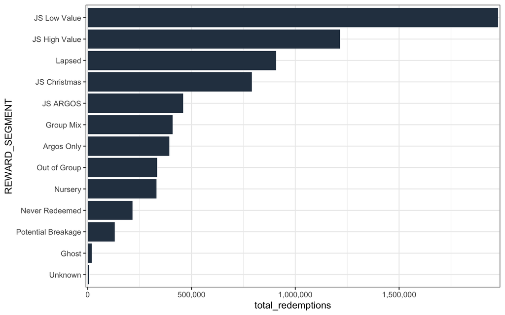

```r
# Some data manipulation first:

Redemptions_by_segment <- Segment_Redemptions %>%

  select(REWARD_SEGMENT,REDEMPTIONS) %>%

  group_by(REWARD_SEGMENT) %>%
  summarize(total_redemptions = sum(REDEMPTIONS)) %>%
  ungroup()

# Plot the bar:

Redemptions_by_segment %>%
  filter(REWARD_SEGMENT != is.na(REWARD_SEGMENT)) %>%
  mutate(REWARD_SEGMENT = REWARD_SEGMENT %>% as_factor() %>% fct_reorder(total_redemptions)) %>%

  ggplot(aes(REWARD_SEGMENT, total_redemptions)) +
  scale_y_continuous(labels= scales::comma_format(), expand = c(0.005,0.005))+
  geom_col(fill = "#2c3e50") +
  coord_flip()
```

## Histogram/Density plots

Another useful type of chart is a histogram or density plot, they are useful for inspecting the distribution of a specific variable:

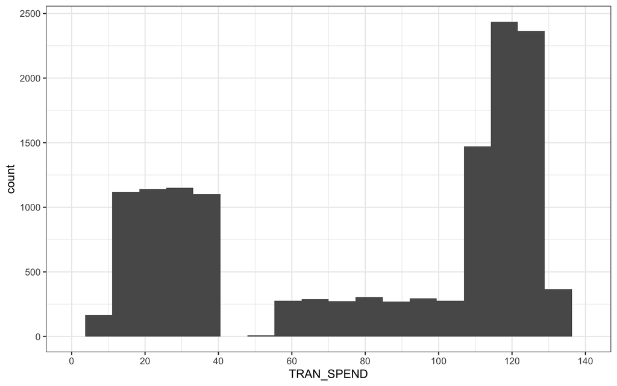

```r
Sample_data %>%
  ggplot(aes(TRAN_SPEND)) +
  geom_histogram(bins = 20) +
  scale_x_continuous(limits = c(0, 140), breaks = seq(0, 140, by = 20)) +
  #facet_wrap( ~ NECTAR_SEGMENT) + # if we want to do it to all segments.+
  theme_bw()
```

In the same family we can consider the box-plot, which is useful for comparing distributions across groups:

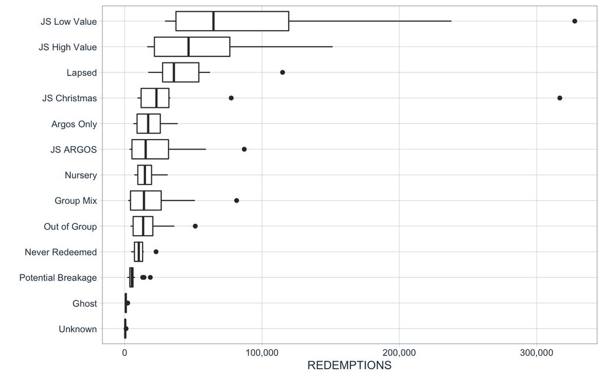

```r
# Box Plot
Segment_Redemptions %>%
  filter(REWARD_SEGMENT != is.na(REWARD_SEGMENT)) %>%

    ggplot(aes(fct_reorder(REWARD_SEGMENT, REDEMPTIONS), REDEMPTIONS)) +

    geom_boxplot() +
    coord_flip() +
    theme_tq()+
    xlab("")+
  scale_y_continuous(labels = scales::comma_format())
```

# Formatting

Formatting involves tweaking and perfecting aspects of the visualization as you see fit. Formatting the colors of a ggplot object:

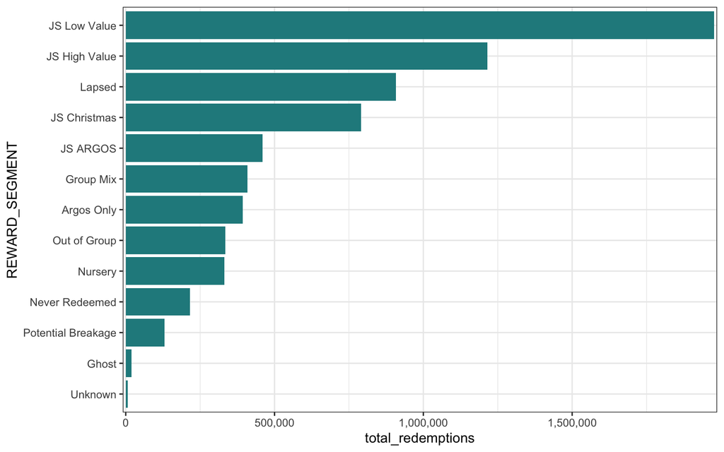

```r
Redemptions_by_segment %>%
  filter(REWARD_SEGMENT != is.na(REWARD_SEGMENT)) %>%
  mutate(REWARD_SEGMENT = REWARD_SEGMENT %>% as_factor() %>% fct_reorder(total_redemptions)) %>%

  ggplot(aes(REWARD_SEGMENT, total_redemptions)) +
  scale_y_continuous(labels= scales::comma_format(), expand = c(0.005,0.005))+ # Examples of Formatting
  geom_col(fill = viridisLite::viridis(n = 20)[10])+ # Examples of Formatting
  coord_flip() # Examples of Formatting
```

R also provides some functionality to convert color schemes from RGB to HEX and vice versa.

```r
# To RGB
col2rgb("slateblue")
```

```
##       [,1]
## red    106
## green   90
## blue   205
```

```r
col2rgb("#2C3E50")
```

```
##       [,1]
## red     44
## green   62
## blue    80
```

```r
# To HEX
rgb(44, 62, 80, maxColorValue = 255)
```

```
## [1] "#2C3E50"
```

This will be useful when customizing and themeing plots.

# Exercises

## Number of redemptions by financial period

For this exercise we will create a graph that breaks down the number of redemptions by financial period. Hint: the data frame you will need to use is Segment_Redemptions, some data wrangling is required, fill in the remaining arguments below:

```r
# Data wrangling:
Exercise1 <- Segment_Redemptions %>%
  group_by(___) %>% #Grouping variable, what is it?
  summarise(Total_Redemptions = sum(___)) %>%  #What variable are we trying to aggregate?
  mutate(FIN_PERIOD_NO = as.factor(FIN_PERIOD_NO))
```

## 1.1 Building the plot

Create the plot for the volume of redemptions by financial period, fill in the arguments in the code below:

```r
Exercise1 %>%
  ggplot(aes()) %>% # specify the variables you want to visualise
  geom_col()
```

## 1.2 Formatting the plot part 1

Format the y-axis such that the numbers have commas. Hint: you will need to add the following function to you plot: `scale_y_continuous()` and pass a specific value to the label that will be the following `scales::comma_format()`. You will need the scales package for this to work!

```r
Exercise1 %>%
 ggplot()+ # Carry on the second argument from part 1.1
 geom_col() + # Geom_layer
  # scale_y_continuous_layer
```

If you are struggling with the above try the following link for inspiration: https://scales.r-lib.org/

## 1.2 Formatting the plot part 2

Let’s continue formatting the plot by adding and formatting the plot title and axis titles. This can be done by adding the labs() function to the plot layers.

```r
# Carry on the layers from the previous 2 exercises and add:
+ labs()
```

run ?labs() in the console to get an idea for the arguments that need to be passed to the function to change the labels.

Finish off the plot by layering a theme onto your plot, call the *theme*() family of functions and pick one that you like.

## Conclusions

Can you think of anything else that would make the plot more appealing? Which financial period had the highest number of redemptions?